[OHI British Columbia](http://www.ohibc.org/) | [OHI Science](http://ohi-science.org) | [Citation policy](https://github.com/OHI-Science/ohiprep/releases)

# OHIBC: Calculate All Scores

Compiled on Tue Aug 13 18:39:24 2019 by ohara

```r
knitr::opts_chunk$set(fig.width = 6, fig.height = 4, fig.path = 'Figs/',
                      echo = TRUE, message = FALSE, warning = FALSE)

library(ohicore) ### devtools::install_github('ohi-science/ohicore@dev')

source('~/github/ohibc/src/R/common.R')

dir_ohibc  <- '~/github/ohibc'
dir_calc   <- file.path(dir_ohibc, 'calc_ohibc')
dir_master <- file.path(dir_calc, 'master')

source(file.path(dir_calc, 'calc_scores_fxns.R'))

### provenance tracking
# library(provRmd); prov_setup()
```

# 1 Set up scenarios

Set up scenarios by assigning years. Each scenario (eg. ‘region2015’) will be tied to a specific data year, not floating as in global OHI.

- Prepare scenario folders
  - create scenario dirs and subdirs
  - copy config files from master to scenarios
- Copy layers from prep to layers folder #####
  - Read in the layers.csv file with paths to the data files
  - Register layers based on include == TRUE and identify file locations
  - check that all data layers are available based on file paths
  - copy layers into current layers folder
- Check that all layers conform with details in config (`layers.csv`)

```r
prep_scenario_dirs(dir_calc, dir_master, master_flag = '_master', purge = TRUE)
# prep_scenario_dirs(dir_calc2, dir_master, master_flag = '_master_scenario2', purge = TRUE)

### copy layers from data sources to layers folder
message('Copying all layers to ', file.path(dir_calc, 'layers'))

layers_log <- assemble_layers_csv(dir_master) %>%
  mutate(dir_prep = file.path(dir_ohibc, str_replace(dir_prep, 'ohibc:', '')))

lyrs <- register_layers(layers_log, dir_calc)

verify_layers(lyrs)

copy_layers_to_scenario(lyrs)

lyrs_files <- list.files(file.path(dir_calc, 'layers'), full.names = TRUE)
lyrs_yrs <- lapply(lyrs_files, read_csv) %>%
  setNames(basename(lyrs_files %>% str_replace('.csv', ''))) %>%
  bind_rows(.id = 'layer') %>%
  select('layer', 'year') %>%
  distinct() %>%
  group_by(layer) %>%
  summarize(yr_span = paste0(min(year, na.rm = TRUE), ':', max(year, na.rm = TRUE)),
            yr_span = ifelse(sum(is.na(year)) == n(), 'NA', yr_span))


write_csv(lyrs %>%
            left_join(lyrs_yrs, by = 'layer') %>%
            select(-path_in, -path_in_exists, -path_out),
          file.path(dir_calc, 'layers.csv'))

### confirm all layers conform to details of layers.csv
conf   <- Conf(file.path(dir_calc, 'conf'))

capture.output( ### the function prints a lot crap to screen - let's change those to messages please!
  {
    CheckLayers(layers.csv = file.path(dir_calc, 'layers.csv'),
                layers.dir = file.path(dir_calc, 'layers'),
                flds_id    = conf$config$layers_id_fields)
  },
  file = 'delete_this.txt')
unlink('delete_this.txt')
```

# 2 Iterate across scenario years

- Initialize conf, layers; store working directory in `layers$data$dir_calc` so it can be accessed by `functions.R`
- Initialize scores_all dataframe to hold scores for all years
- Calculate scores for each scenario and append to scores_all

*NOTE:* These scores are based on uncapped resilience scores, which in this case typically means resilience is much higher than pressures. In the later chunk we recalculate resilience by capping to the amount of pressure, and then recalculate likely future state manually.

```r
conf   <- Conf(file.path(dir_calc, 'conf'))
layers <- Layers(layers.csv = file.path(dir_calc, 'layers.csv'),
                 layers.dir = file.path(dir_calc, 'layers'))

layers$data$dir_calc   <- dir_calc
layers$data$scenario_data_years <- read_csv(file.path(dir_calc, 'conf/scenario_data_years.csv'))
layers$data$status_year_span <- layers$data$scenario_data_years %>%
  .$scenario_year %>% unique() %>% sort()

status_years <- layers$data$status_year_span

### for testing:
status_year <- 2012
layers$data$scenario_year <- status_year
```

```r
scores_all <- data.frame() ### initialize scores

for (status_year in status_years) {

  message('Calculating scores for ', status_year)

  ### For each run through loop, assign status_year inside
  ###   the layers object/env't so it is accessible to functions.R
  layers$data$scenario_year <- status_year

  capture.output( ### the function prints crap to screen
    {
      scores <- CalculateAll(conf, layers) %>%
        mutate(yr_text = status_year,
               year    = as.integer(str_replace_all(status_year, '[^0-9]', '')))
    },
    file = 'delete_this.txt')
  unlink('delete_this.txt')

  scores_all <- scores_all %>%
    bind_rows(scores)

}

write_csv(scores_all, file.path(dir_calc, 'scores_all_uncapped_res.csv'))
```

# 3 Update resilience and pressure calculations for Likely Future State

Resilience is generally quite high relative to pressures. The idea of resilience is that legal, social, and ecological systems are in place to address pressures, so once pressures are addressed, these systems should not further be counted toward improving OHI scores.

This chunk manually recalculates Likely Future State by capping resilience values such that they do not exceed pressure values. This is done after all pressures and resilience measures have been combined and weighted.

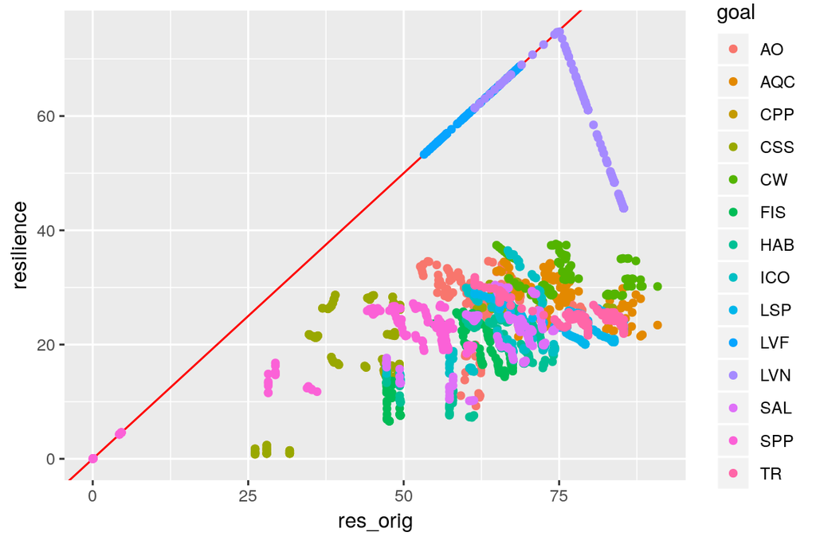

```r
scores_all <- read_csv(file.path(dir_calc, 'scores_all_uncapped_res.csv')) %>%
  select(-yr_text)

beta <- .67; delta <- 1

scores_wide <- scores_all %>%
  filter(region_id != 0) %>%
  spread(dimension, score) %>%
  filter(!is.na(resilience) & !is.na(pressures)) %>%
    ### note: this drops supragoals, intentionally
  rename(future_orig = future, res_orig = resilience) %>%
  mutate(trend = ifelse(is.na(trend), 0, trend),
           ### NA trends convert to 0 for calculating future state?
         resilience = ifelse(res_orig > pressures, pressures, res_orig)) %>%
  mutate(future = status * (1 + beta * trend + (1 - beta) * (resilience - pressures)/100),
         future = ifelse(future > 100, 100, future)) %>%
  mutate(score_orig = score,
         score = (status + future) / 2)

# x <- scores_wide %>%
#   filter(score_orig < score)
ggplot(scores_wide, aes(x = res_orig, y = resilience, color = goal)) +
  geom_abline(intercept = 0, slope = 1, color = 'red') +
  geom_point()
```

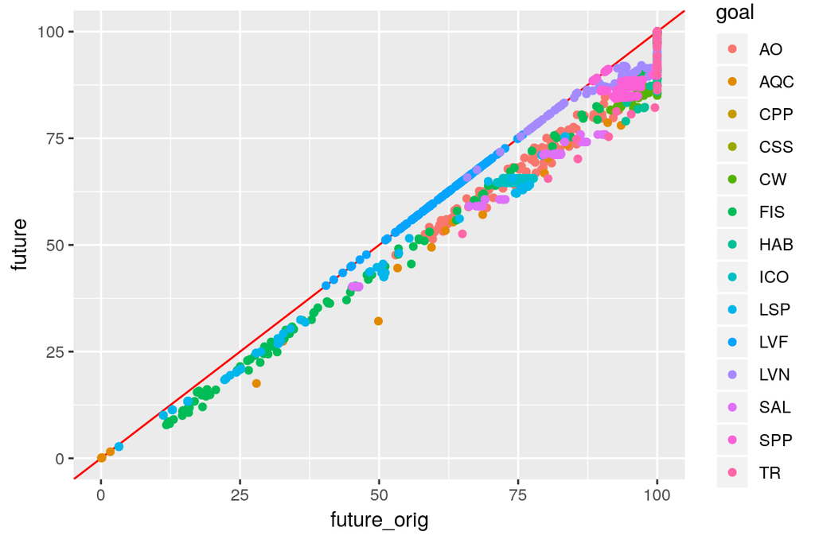

```r
ggplot(scores_wide, aes(x = future_orig, y = future, color = goal)) +
  geom_abline(intercept = 0, slope = 1, color = 'red') +
  geom_point()
```

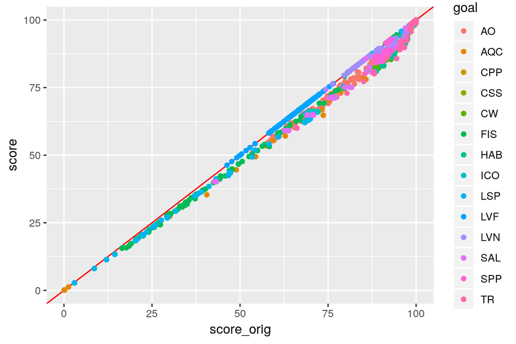

```r
ggplot(scores_wide, aes(x = score_orig, y = score, color = goal)) +
  geom_abline(intercept = 0, slope = 1, color = 'red') +
  geom_point()
```

## 3.1 gather supragoals; attach to subgoals and complete goals

```r
scores_long <- scores_wide %>%
  select(-ends_with('orig')) %>%
  gather(dimension, score, pressures:future)

### recalculate supragoals
fp <- scores_long %>%
  filter(goal %in% c('MAR', 'FIS', 'SAL')) %>%
  group_by(year, region_id, dimension) %>%
  summarize(score = mean(score, na.rm = TRUE)) %>%
  filter(!dimension %in% c('pressures', 'resilience')) %>%
  mutate(goal = 'FP')

sp <- scores_long %>%
  filter(goal %in% c('LSP', 'ICO')) %>%
  group_by(year, region_id, dimension) %>%
  summarize(score = mean(score, na.rm = TRUE)) %>%
  filter(!dimension %in% c('pressures', 'resilience')) %>%
  mutate(goal = 'SP')

bd <- scores_long %>%
  filter(goal %in% c('SPP', 'HAB')) %>%
  group_by(year, region_id, dimension) %>%
  summarize(score = mean(score, na.rm = TRUE)) %>%
  filter(!dimension %in% c('pressures', 'resilience')) %>%
  mutate(goal = 'BD')

hs <- scores_long %>%
  filter(goal %in% c('CPP', 'CSS')) %>%
  group_by(year, region_id, dimension) %>%
  summarize(score = mean(score, na.rm = TRUE)) %>%
  filter(!dimension %in% c('pressures', 'resilience')) %>%
  mutate(goal = 'HS')

lv <- scores_long %>%
  filter(goal %in% c('LVF', 'LVO')) %>%
  group_by(year, region_id, dimension) %>%
  summarize(score = mean(score, na.rm = TRUE)) %>%
  filter(!dimension %in% c('pressures', 'resilience')) %>%
  mutate(goal = 'LV')

scores_w_supra <- scores_long %>%
  bind_rows(fp, sp, bd, hs, lv)

### generate index scores for each region
scores_rgn_index <- scores_w_supra %>%
  filter(nchar(goal) == 2) %>%
  filter(dimension %in% c('status', 'future', 'score')) %>%
  group_by(region_id, year, dimension) %>%
  summarize(score = mean(score, na.rm = TRUE),
            goal = 'Index')

scores_w_index <- scores_w_supra %>%
  bind_rows(scores_rgn_index)

### Then need to aggregate up to overall BC region
rgn_areas <- read_csv(file.path(dir_ohibc, 'prep/_spatial/v2017',
                                'output/rgn_areas_no_offshore.csv'))
scores_ohibc <- scores_w_index %>%
  filter(dimension %in% c('status', 'score', 'future')) %>%
  left_join(rgn_areas, by = c('region_id' = 'rgn_id')) %>%
  group_by(goal, year, dimension) %>%
  summarize(score = weighted.mean(score, w = area_km2, na.rm = TRUE),
            region_id = 0)

scores_new_res <- scores_w_index %>%
  bind_rows(scores_ohibc)

write_csv(scores_new_res, file.path(dir_calc, 'scores_all.csv'))
```

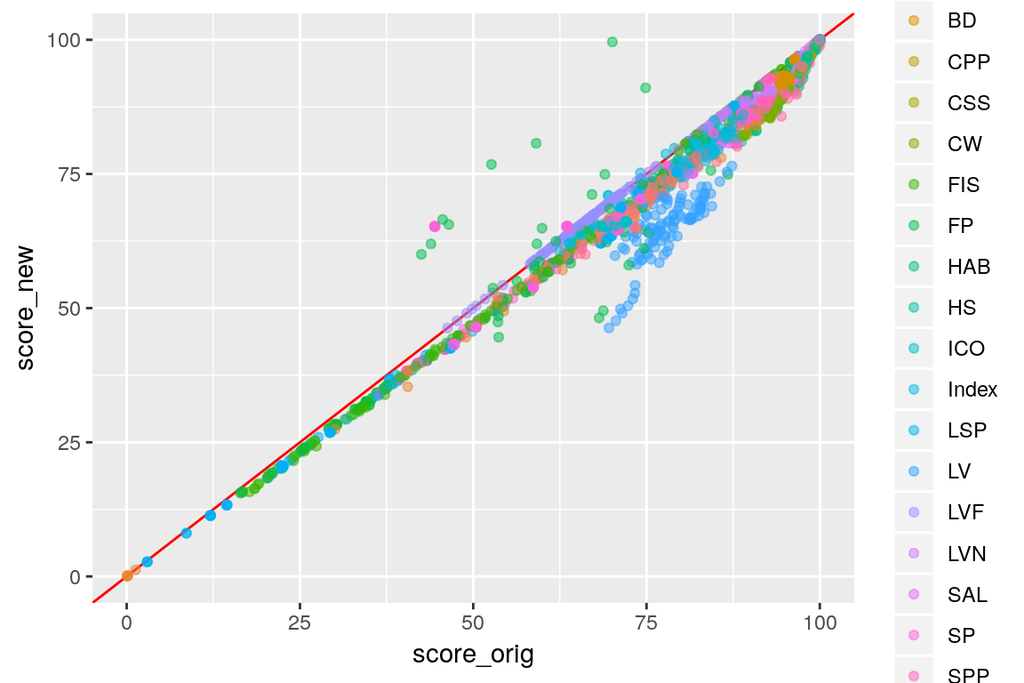

```r
scores_orig <- read_csv(file.path(dir_calc, 'scores_all_uncapped_res.csv')) %>%
  rename(score_orig = score)
scores_new <- read_csv(file.path(dir_calc, 'scores_all.csv')) %>%
  rename(score_new = score)

scores_compare <- scores_orig %>%
  left_join(scores_new, by = c('region_id', 'year', 'goal', 'dimension'))

x <- scores_compare %>%
  filter(dimension == 'score') %>%
  filter(round(score_new, 3) > round(score_orig, 3))

y <- scores_compare %>%
  filter(goal %in% c('FP', 'FIS', 'MAR', 'SAL')) %>%
  filter(year == 2006) %>%
  filter(region_id == 3)

ggplot(scores_compare %>%
         # filter(goal %in% c('FP', 'FIS', 'MAR', 'SAL')) %>%
         filter(dimension == 'score'),
       aes(x = score_orig, y = score_new, color = goal)) +
  geom_abline(intercept = 0, slope = 1, color = 'red') +
  geom_point(alpha = .5)
```

# 4 Rerun scores to capture resilience components

Here we do not need to recalculate all the scores, but just the goal-specific resilience (these will be compared to status, as calculated above). To do this, I will rerun the whole process, but rename (in the copied layers folder, not master) `resilience_matrix_reg_master.csv` -> `resilience_matrix.csv`. Then all scores except resilience will be deleted, and the new .csv saved. Repeat this for `resilience_matrix_soc_master.csv` and `resilience_matrix_ecol_master.csv`.

Note also the CWB needs to be removed from the pressures (eliminating social pressures! hrrrmm) to avoid collinearity with the social resilience layer (which includes CWB). This is performed in the first block.

```r
message('Calculating governance-only resilience...')
### copy governance resilience csv to overwrite overall resilience matrix
### (rewriting the conf copy, not the master copy!)
file.copy(from = file.path(dir_calc, 'master', 'resilience_matrix_reg_master.csv'),
          to   = file.path(dir_calc, 'conf', 'resilience_matrix.csv'),
          overwrite = TRUE)
```

```
## [1] TRUE
```

```r
file.copy(from = file.path(dir_calc, 'master', 'pressures_matrix_no_cwb_master.csv'),
          to   = file.path(dir_calc, 'conf', 'pressures_matrix.csv'),
          overwrite = TRUE)
```

```
## [1] TRUE
```

```r
conf   <- Conf(file.path(dir_calc, 'conf'))

scores_all <- data.frame() ### initialize scores

for (status_year in status_years) {

  message('Calculating scores for ', status_year)

  ### For each run through loop, assign status_year inside
  ###   the layers object/env't so it is accessible to functions.R
  layers$data$scenario_year <- status_year

  capture.output( ### the function prints crap to screen
    {
      scores <- CalculateAll(conf, layers) %>%
        mutate(yr_text = status_year,
               year    = as.integer(str_replace_all(status_year, '[^0-9]', '')))
    },
    file = 'delete_this.txt')
  unlink('delete_this.txt')

  scores_all <- scores_all %>%
    bind_rows(scores)

}

prs_scores_all <- scores_all %>%
  filter(dimension == 'pressures')
res_scores_all <- scores_all %>%
  filter(dimension == 'resilience')

tmp <- read_csv(file.path(dir_calc, 'scores_all.csv')) %>%
  spread(dimension, score) %>%
  left_join(res_scores_all %>% mutate(dimension = 'res_reg') %>% spread(dimension, score))
tmp <- read_csv(file.path(dir_calc, 'scores_all.csv')) %>%
  spread(dimension, score) %>%
  left_join(prs_scores_all %>% mutate(dimension = 'prs_no_social') %>% spread(dimension, score))

write_csv(prs_scores_all, file.path(dir_calc, 'prs_no_social.csv'))
write_csv(res_scores_all, file.path(dir_calc, 'res_reg_only.csv'))
```

```r
message('Calculating social-only resilience...')
### copy social resilience csv to overwrite overall resilience matrix
### (rewriting the conf copy, not the master copy!)
file.copy(from = file.path(dir_calc, 'master', 'resilience_matrix_soc_master.csv'),
          to   = file.path(dir_calc, 'conf', 'resilience_matrix.csv'),
          overwrite = TRUE)
```

```
## [1] TRUE
```

```r
conf   <- Conf(file.path(dir_calc, 'conf'))

res_scores_all <- data.frame() ### initialize scores

for (status_year in status_years) {

  message('Calculating scores for ', status_year)

  ### For each run through loop, assign status_year inside
  ###   the layers object/env't so it is accessible to functions.R
  layers$data$scenario_year <- status_year

  capture.output( ### the function prints crap to screen
    {
      scores <- CalculateAll(conf, layers) %>%
        mutate(yr_text = status_year,
               year    = as.integer(str_replace_all(status_year, '[^0-9]', '')))
    },
    file = 'delete_this.txt')
  unlink('delete_this.txt')

  res_scores_all <- res_scores_all %>%
    bind_rows(scores)

}

res_scores_all <- res_scores_all %>%
  filter(dimension == 'resilience')

tmp <- read_csv(file.path(dir_calc, 'scores_all.csv')) %>%
  spread(dimension, score) %>%
  left_join(res_scores_all %>% mutate(dimension = 'res_soc') %>% spread(dimension, score))

write_csv(res_scores_all, file.path(dir_calc, 'res_soc_only.csv'))
```

```r
message('Calculating ecological-only resilience...')
### copy ecological resilience csv to overwrite overall resilience matrix
### (rewriting the conf copy, not the master copy!)
file.copy(from = file.path(dir_calc, 'master', 'resilience_matrix_ecol_master.csv'),
          to   = file.path(dir_calc, 'conf', 'resilience_matrix.csv'),
          overwrite = TRUE)
```

```
## [1] TRUE
```

```r
conf   <- Conf(file.path(dir_calc, 'conf'))

res_scores_all <- data.frame() ### initialize scores

for (status_year in status_years) {

  message('Calculating scores for ', status_year)

  ### For each run through loop, assign status_year inside
  ###   the layers object/env't so it is accessible to functions.R
  layers$data$scenario_year <- status_year

  capture.output( ### the function prints crap to screen
    {
      scores <- CalculateAll(conf, layers) %>%
        mutate(yr_text = status_year,
               year    = as.integer(str_replace_all(status_year, '[^0-9]', '')))
    },
    file = 'delete_this.txt')
  unlink('delete_this.txt')

  res_scores_all <- res_scores_all %>%
    bind_rows(scores)

}

res_scores_all <- res_scores_all %>%
  filter(dimension == 'resilience')

tmp <- read_csv(file.path(dir_calc, 'scores_all.csv')) %>%
  spread(dimension, score) %>%
  left_join(res_scores_all %>% mutate(dimension = 'res_ecol') %>% spread(dimension, score))

write_csv(res_scores_all, file.path(dir_calc, 'res_ecol_only.csv'))
```

```r
# prov_wrapup(commit_outputs = FALSE)
```